# CASE STUDY : BREAST CANCER CLASSIFICATION (COIMBRA DATASET)

Breast cancer is a disease characterized by cells in the breast that become abnormal and multiply uncontrollably, forming a tumor. If left untreated, malignant cells may eventually spread beyond the original tumor to other parts of the body, a process called metastasis. Breast cancer is the most common type of cancer in women worldwide. Every year approximately **124 out of 100,000** women are diagnosed with breast cancer and the estimation is that 23 out of the 124 will die due to this disease.

When detected in its early stages, there is a **30%** chance that the cancer can be treated eﬀectively, but the late detection of advanced-stage tumors makes the treatment more diﬃcult. In this project, different machine learning classifier algorithms are compared based on various metrics parameters. To create the classifier, University of Coimbra (Breast Cancer Coimbra) dataset is employed. Before performing the tests, a large fraction of this work will be dedicated for pre-processing the data in order to optimize the classiﬁer.

The dataset used is publically available in **UCI Machine learning repository** and was created by Miguel Patrício, José Pereira , Joana Crisóstomo , Paulo Matafome , Raquel Seiça , Francisco Caramelo , all from the Faculty of Medicine of the University of Coimbra and also Manuel Gomes from the **University Hospital Centre of Coimbra**.

The dataset contains clinical features that were observed or measured for 64 patients with breast cancer and 52 healthy controls. Total number of instances 116.

In this project, I have developed and explored the power of support vector machine in classifying whether the person has breast cancer or he/she is healthy.

**Summary of DataSet**

[figure not shown]

```python
import numpy as np
import matplotlib.pyplot as plt
import pandas as pd
import seaborn as sns
import visuals as vs
%matplotlib inline
```

```python
df=pd.read_csv('breast_cancer_coimbra.csv')
```

```python
df.head()
```

|  | Age | BMI | Glucose | Insulin | HOMA | Leptin | Adiponectin | Resistin | MCP.1 | Classification |
| --- | --- | --- | --- | --- | --- | --- | --- | --- | --- | --- |
| 0 | 48 | 23.500000 | 70 | 2.707 | 0.467409 | 8.8071 | 9.702400 | 7.99585 | 417.114 | 1 |
| 1 | 83 | 20.690495 | 92 | 3.115 | 0.706897 | 8.8438 | 5.429285 | 4.06405 | 468.786 | 1 |
| 2 | 82 | 23.124670 | 91 | 4.498 | 1.009651 | 17.9393 | 22.432040 | 9.27715 | 554.697 | 1 |
| 3 | 68 | 21.367521 | 77 | 3.226 | 0.612725 | 9.8827 | 7.169560 | 12.76600 | 928.220 | 1 |
| 4 | 86 | 21.111111 | 92 | 3.549 | 0.805386 | 6.6994 | 4.819240 | 10.57635 | 773.920 | 1 |

```python
df.tail()
```

|  | Age | BMI | Glucose | Insulin | HOMA | Leptin | Adiponectin | Resistin | MCP.1 | Classification |
| --- | --- | --- | --- | --- | --- | --- | --- | --- | --- | --- |
| 111 | 45 | 26.85 | 92 | 3.33 | 0.755688 | 54.68 | 12.10 | 10.96 | 268.23 | 2 |
| 112 | 62 | 26.84 | 100 | 4.53 | 1.117400 | 12.45 | 21.42 | 7.32 | 330.16 | 2 |
| 113 | 65 | 32.05 | 97 | 5.73 | 1.370998 | 61.48 | 22.54 | 10.33 | 314.05 | 2 |
| 114 | 72 | 25.59 | 82 | 2.82 | 0.570392 | 24.96 | 33.75 | 3.27 | 392.46 | 2 |
| 115 | 86 | 27.18 | 138 | 19.91 | 6.777364 | 90.28 | 14.11 | 4.35 | 90.09 | 2 |

```python
df.head()
```

|  | Age | BMI | Glucose | Insulin | HOMA | Leptin | Adiponectin | Resistin | MCP.1 | Classification |
| --- | --- | --- | --- | --- | --- | --- | --- | --- | --- | --- |
| 0 | 48 | 23.500000 | 70 | 2.707 | 0.467409 | 8.8071 | 9.702400 | 7.99585 | 417.114 | 1 |
| 1 | 83 | 20.690495 | 92 | 3.115 | 0.706897 | 8.8438 | 5.429285 | 4.06405 | 468.786 | 1 |
| 2 | 82 | 23.124670 | 91 | 4.498 | 1.009651 | 17.9393 | 22.432040 | 9.27715 | 554.697 | 1 |
| 3 | 68 | 21.367521 | 77 | 3.226 | 0.612725 | 9.8827 | 7.169560 | 12.76600 | 928.220 | 1 |
| 4 | 86 | 21.111111 | 92 | 3.549 | 0.805386 | 6.6994 | 4.819240 | 10.57635 | 773.920 | 1 |

```python
df.shape
```

```
(116, 10)
```

```python
print(df.dtypes)
```

```
Age                 int64
BMI               float64
Glucose             int64
Insulin           float64
HOMA              float64
Leptin            float64
Adiponectin       float64
Resistin          float64
MCP.1             float64
Classification      int64
dtype: object
```

```python
df.isnull().sum()
```

```
Age               0
BMI               0
Glucose           0
Insulin           0
HOMA              0
Leptin            0
Adiponectin       0
Resistin          0
MCP.1             0
Classification    0
dtype: int64
```

```python
df.describe()
```

|  | Age | BMI | Glucose | Insulin | HOMA | Leptin | Adiponectin | Resistin | MCP.1 | Classification |
| --- | --- | --- | --- | --- | --- | --- | --- | --- | --- | --- |
| count | 116.000000 | 116.000000 | 116.000000 | 116.000000 | 116.000000 | 116.000000 | 116.000000 | 116.000000 | 116.000000 | 116.000000 |
| mean | 57.301724 | 27.582111 | 97.793103 | 10.012086 | 2.694988 | 26.615080 | 10.180874 | 14.725966 | 534.647000 | 1.551724 |
| std | 16.112766 | 5.020136 | 22.525162 | 10.067768 | 3.642043 | 19.183294 | 6.843341 | 12.390646 | 345.912663 | 0.499475 |
| min | 24.000000 | 18.370000 | 60.000000 | 2.432000 | 0.467409 | 4.311000 | 1.656020 | 3.210000 | 45.843000 | 1.000000 |
| 25% | 45.000000 | 22.973205 | 85.750000 | 4.359250 | 0.917966 | 12.313675 | 5.474282 | 6.881763 | 269.978250 | 1.000000 |
| 50% | 56.000000 | 27.662416 | 92.000000 | 5.924500 | 1.380939 | 20.271000 | 8.352692 | 10.827740 | 471.322500 | 2.000000 |
| 75% | 71.000000 | 31.241442 | 102.000000 | 11.189250 | 2.857787 | 37.378300 | 11.815970 | 17.755207 | 700.085000 | 2.000000 |
| max | 89.000000 | 38.578759 | 201.000000 | 58.460000 | 25.050342 | 90.280000 | 38.040000 | 82.100000 | 1698.440000 | 2.000000 |

As target variable Classification value 1 means healthy controls and 2 means cancer patient so we will replace 1 to 0 and 2 to1 means now healthy people has value 0 and cancer patients have value 1

```python
df['Classification'].replace(
    to_replace=[1],
    value=0,
    inplace=True
)
```

```python
df['Classification'].replace(
    to_replace=[2],
    value=1,
    inplace=True
)
```

```python
df.head()
```

|  | Age | BMI | Glucose | Insulin | HOMA | Leptin | Adiponectin | Resistin | MCP.1 | Classification |
| --- | --- | --- | --- | --- | --- | --- | --- | --- | --- | --- |
| 0 | 48 | 23.500000 | 70 | 2.707 | 0.467409 | 8.8071 | 9.702400 | 7.99585 | 417.114 | 0 |
| 1 | 83 | 20.690495 | 92 | 3.115 | 0.706897 | 8.8438 | 5.429285 | 4.06405 | 468.786 | 0 |
| 2 | 82 | 23.124670 | 91 | 4.498 | 1.009651 | 17.9393 | 22.432040 | 9.27715 | 554.697 | 0 |
| 3 | 68 | 21.367521 | 77 | 3.226 | 0.612725 | 9.8827 | 7.169560 | 12.76600 | 928.220 | 0 |
| 4 | 86 | 21.111111 | 92 | 3.549 | 0.805386 | 6.6994 | 4.819240 | 10.57635 | 773.920 | 0 |

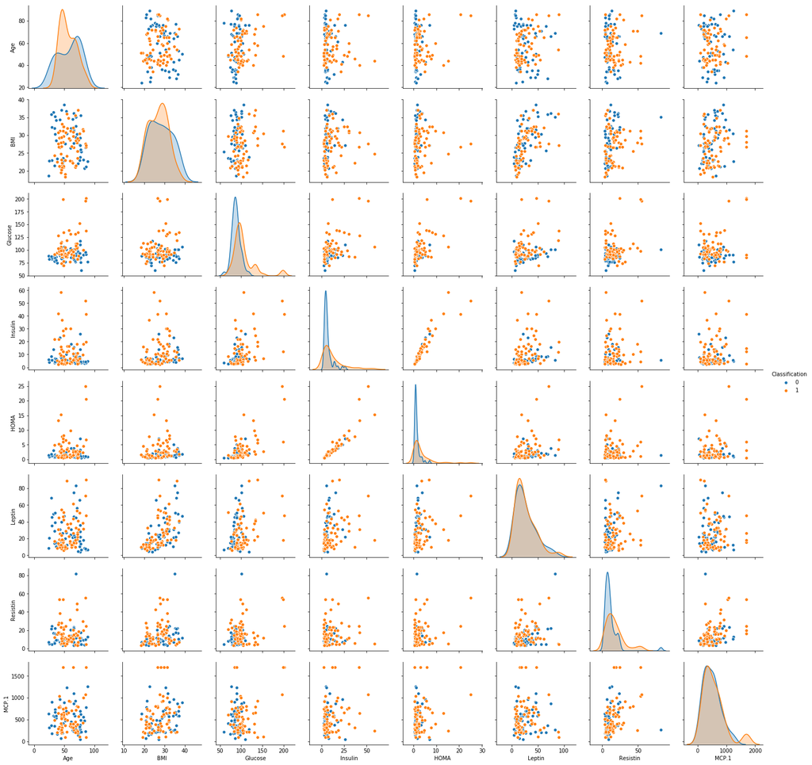

```python
sns.pairplot(df, hue = 'Classification', vars = ['Age', 'BMI', 'Glucose', 'Insulin', 'HOMA', 'Leptin','Resistin','MCP.1'] )
```

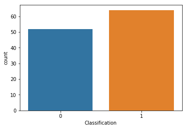

```python
sns.countplot(df['Classification'], label = "Count")
```

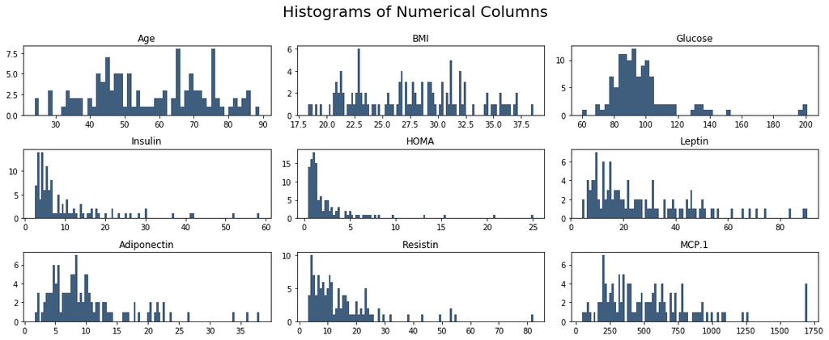

```python
dataset2 = df.drop(columns = ['Classification'])

fig = plt.figure(figsize=(15, 12))
plt.suptitle('Histograms of Numerical Columns', fontsize=20)
for i in range(dataset2.shape[1]):
    plt.subplot(6, 3, i + 1)
    f = plt.gca()
    f.set_title(dataset2.columns.values[i])

    vals = np.size(dataset2.iloc[:, i].unique())
    if vals >= 100:
        vals = 100

    plt.hist(dataset2.iloc[:, i], bins=vals, color='#3F5D7D')
plt.tight_layout(rect=[0, 0.03, 1, 0.95])
```

# Correlation with Target Variable Classification

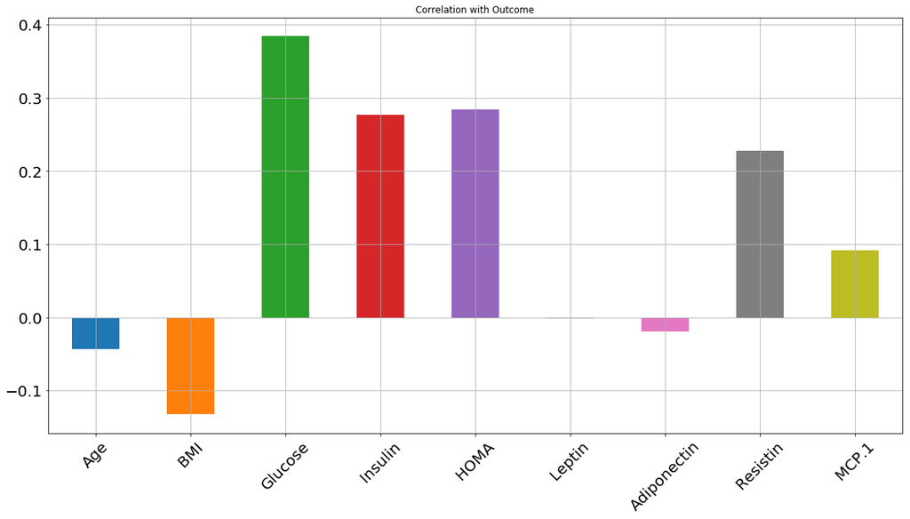

```python
dataset2.corrwith(df.Classification).plot.bar(
        figsize = (20, 10), title = "Correlation with Outcome", fontsize = 20,
        rot = 45, grid = True)
```

```python
X = df.drop(['Classification'],axis=1)
```

```python
X.head()
```

|  | Age | BMI | Glucose | Insulin | HOMA | Leptin | Adiponectin | Resistin | MCP.1 |
| --- | --- | --- | --- | --- | --- | --- | --- | --- | --- |
| 0 | 48 | 23.500000 | 70 | 2.707 | 0.467409 | 8.8071 | 9.702400 | 7.99585 | 417.114 |
| 1 | 83 | 20.690495 | 92 | 3.115 | 0.706897 | 8.8438 | 5.429285 | 4.06405 | 468.786 |
| 2 | 82 | 23.124670 | 91 | 4.498 | 1.009651 | 17.9393 | 22.432040 | 9.27715 | 554.697 |
| 3 | 68 | 21.367521 | 77 | 3.226 | 0.612725 | 9.8827 | 7.169560 | 12.76600 | 928.220 |
| 4 | 86 | 21.111111 | 92 | 3.549 | 0.805386 | 6.6994 | 4.819240 | 10.57635 | 773.920 |

```python
y=df['Classification']
```

```python
y.head()
```

```
0    0
1    0
2    0
3    0
4    0
Name: Classification, dtype: int64
```

```python
from sklearn.model_selection import train_test_split

X_train, X_test, y_train, y_test = train_test_split(X, y, test_size = 0.20, random_state=5)
```

```python
from sklearn.svm import SVC
from sklearn.metrics import classification_report, confusion_matrix

svc_model = SVC()
svc_model.fit(X_train, y_train)
```

```
SVC(C=1.0, cache_size=200, class_weight=None, coef0=0.0,
  decision_function_shape='ovr', degree=3, gamma='auto', kernel='rbf',
  max_iter=-1, probability=False, random_state=None, shrinking=True,
  tol=0.001, verbose=False)
```

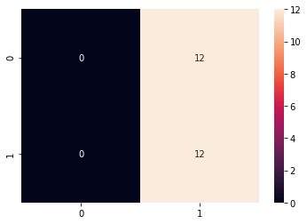

```python
y_predict = svc_model.predict(X_test)
cm = confusion_matrix(y_test, y_predict)
sns.heatmap(cm, annot=True)
```

```python
from sklearn.metrics import  accuracy_score, f1_score, precision_score, recall_score
acc = accuracy_score(y_test, y_predict)
prec = precision_score(y_test, y_predict)
rec = recall_score(y_test, y_predict)
f1 = f1_score(y_test, y_predict)

results = pd.DataFrame([['Support Vector Machine-Not scaled', acc,prec,rec, f1]],
               columns = ['Model', 'Accuracy', 'Precision', 'Recall', 'F1 Score'])
results
```

|  | Model | Accuracy | Precision | Recall | F1 Score |
| --- | --- | --- | --- | --- | --- |
| 0 | Support Vector Machine-Not scaled | 0.5 | 0.5 | 1.0 | 0.666667 |

```python
min_train = X_train.min()
range_train = (X_train - min_train).max()
X_train_scaled = (X_train - min_train)/range_train
```

```python
min_test = X_test.min()
range_test = (X_test - min_test).max()
X_test_scaled = (X_test - min_test)/range_test
```

```python
from sklearn.svm import SVC
from sklearn.metrics import classification_report, confusion_matrix

svc_model = SVC()
svc_model.fit(X_train_scaled, y_train)
```

```
SVC(C=1.0, cache_size=200, class_weight=None, coef0=0.0,
  decision_function_shape='ovr', degree=3, gamma='auto', kernel='rbf',
  max_iter=-1, probability=False, random_state=None, shrinking=True,
  tol=0.001, verbose=False)
```

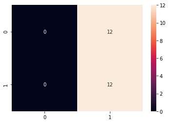

```python
y_predict = svc_model.predict(X_test_scaled)
cm = confusion_matrix(y_test, y_predict)

sns.heatmap(cm,annot=True,fmt="d")
```

```python
from sklearn.metrics import  accuracy_score, f1_score, precision_score, recall_score
from sklearn.metrics import roc_auc_score
roc=roc_auc_score(y_test, y_predict)

acc = accuracy_score(y_test, y_predict)
prec = precision_score(y_test, y_predict)
rec = recall_score(y_test, y_predict)
f1 = f1_score(y_test, y_predict)

results = pd.DataFrame([['Support Vector Machine Un optimized', acc,prec,rec, f1,roc]],
               columns = ['Model', 'Accuracy', 'Precision', 'Recall', 'F1 Score','ROC'])
results
```

|  | Model | Accuracy | Precision | Recall | F1 Score | ROC |
| --- | --- | --- | --- | --- | --- | --- |
| 0 | Support Vector Machine Un optimized | 0.5 | 0.5 | 1.0 | 0.666667 | 0.5 |

```python
from sklearn.model_selection import RandomizedSearchCV, cross_val_score
param_dist = {

    'C':[0.1, 1, 10, 100,1000],
        'gamma':[1, 0.1, 0.01, 0.001],
    'kernel':['rbf','linear']
}

# run randomized search
n_iter_search =20
random_search = RandomizedSearchCV(svc_model, param_distributions=param_dist,
                                   n_iter=n_iter_search, cv=5)


random_search.fit(X_train_scaled,y_train)
```

```
RandomizedSearchCV(cv=5, error_score='raise',
          estimator=SVC(C=1.0, cache_size=200, class_weight=None, coef0=0.0,
  decision_function_shape='ovr', degree=3, gamma='auto', kernel='rbf',
  max_iter=-1, probability=False, random_state=None, shrinking=True,
  tol=0.001, verbose=False),
          fit_params=None, iid=True, n_iter=20, n_jobs=1,
          param_distributions={'C': [0.1, 1, 10, 100, 1000], 'gamma': [1, 0.1, 0.01, 0.001], 'kernel': ['rbf', 'linear']},
          pre_dispatch='2*n_jobs', random_state=None, refit=True,
          return_train_score='warn', scoring=None, verbose=0)
```

```python
random_search.best_params_
```

```
{'kernel': 'rbf', 'gamma': 1, 'C': 10}
```

```python
random_search.best_estimator_
```

```
SVC(C=10, cache_size=200, class_weight=None, coef0=0.0,
  decision_function_shape='ovr', degree=3, gamma=1, kernel='rbf',
  max_iter=-1, probability=False, random_state=None, shrinking=True,
  tol=0.001, verbose=False)
```

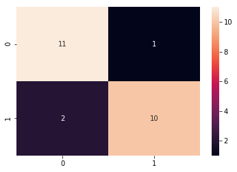

```python
rand_predictions = random_search.predict(X_test_scaled)
cm = confusion_matrix(y_test, rand_predictions)
sns.heatmap(cm,annot=True,fmt="d")
```

```python
from sklearn.metrics import  accuracy_score, f1_score, precision_score, recall_score
from sklearn.metrics import roc_auc_score
roc=roc_auc_score(y_test, rand_predictions)
acc = accuracy_score(y_test, rand_predictions)
prec = precision_score(y_test, rand_predictions)
rec = recall_score(y_test, rand_predictions)
f1 = f1_score(y_test, rand_predictions)

model_results = pd.DataFrame([['Support Vector Machine Optimized', acc,prec,rec, f1,roc]],
               columns = ['Model', 'Accuracy', 'Precision', 'Recall', 'F1 Score','ROC'])
results = results.append(model_results, ignore_index = True)
results
```

|  | Model | Accuracy | Precision | Recall | F1 Score | ROC |
| --- | --- | --- | --- | --- | --- | --- |
| 0 | Support Vector Machine Un optimized | 0.500 | 0.500000 | 1.000000 | 0.666667 | 0.500 |
| 1 | Support Vector Machine Optimized | 0.875 | 0.909091 | 0.833333 | 0.869565 | 0.875 |

```python
from sklearn  import ensemble
gboost =ensemble.GradientBoostingClassifier()
gboost.fit(X_train_scaled, y_train)
```

```
GradientBoostingClassifier(criterion='friedman_mse', init=None,
              learning_rate=0.1, loss='deviance', max_depth=3,
              max_features=None, max_leaf_nodes=None,
              min_impurity_decrease=0.0, min_impurity_split=None,
              min_samples_leaf=1, min_samples_split=2,
              min_weight_fraction_leaf=0.0, n_estimators=100,
              presort='auto', random_state=None, subsample=1.0, verbose=0,
              warm_start=False)
```

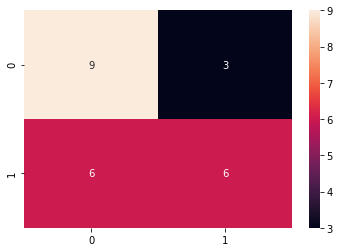

```python
y_predict = gboost.predict(X_test_scaled)
cm = confusion_matrix(y_test, y_predict)

sns.heatmap(cm,annot=True,fmt="d")
```

```python
from sklearn.ensemble import RandomForestClassifier
random_forest = RandomForestClassifier(criterion = 'entropy',  random_state = 42)
random_forest.fit(X_train_scaled, y_train)
```

```
RandomForestClassifier(bootstrap=True, class_weight=None, criterion='entropy',
            max_depth=None, max_features='auto', max_leaf_nodes=None,
            min_impurity_decrease=0.0, min_impurity_split=None,
            min_samples_leaf=1, min_samples_split=2,
            min_weight_fraction_leaf=0.0, n_estimators=10, n_jobs=1,
            oob_score=False, random_state=42, verbose=0, warm_start=False)
```

```python
param_grid = {


 'max_depth': [5,10,15,20],
        'n_estimators': [10,90,100,150,200],
        'max_features':['auto'],
    'min_samples_split':[2, 5, 10],
    'min_samples_leaf': [1, 2, 4],
}
from sklearn.model_selection import GridSearchCV
grid = GridSearchCV(random_forest,param_grid,cv = 5, verbose=2)
grid.fit(X_train_scaled,y_train)
```

[output not shown]

```
[Parallel(n_jobs=1)]: Done   1 out of   1 | elapsed:    0.0s remaining:    0.0s
```

[output not shown]

[output cut: 1734 more lines]

[output not shown]

```
[Parallel(n_jobs=1)]: Done 900 out of 900 | elapsed:  2.3min finished
```

```
GridSearchCV(cv=5, error_score='raise',
       estimator=RandomForestClassifier(bootstrap=True, class_weight=None, criterion='entropy',
            max_depth=None, max_features='auto', max_leaf_nodes=None,
            min_impurity_decrease=0.0, min_impurity_split=None,
            min_samples_leaf=1, min_samples_split=2,
            min_weight_fraction_leaf=0.0, n_estimators=10, n_jobs=1,
            oob_score=False, random_state=42, verbose=0, warm_start=False),
       fit_params=None, iid=True, n_jobs=1,
       param_grid={'max_depth': [5, 10, 15, 20], 'n_estimators': [10, 90, 100, 150, 200], 'max_features': ['auto'], 'min_samples_split': [2, 5, 10], 'min_samples_leaf': [1, 2, 4]},
       pre_dispatch='2*n_jobs', refit=True, return_train_score='warn',
       scoring=None, verbose=2)
```

```python
grid.best_estimator_
```

```
RandomForestClassifier(bootstrap=True, class_weight=None, criterion='entropy',
            max_depth=5, max_features='auto', max_leaf_nodes=None,
            min_impurity_decrease=0.0, min_impurity_split=None,
            min_samples_leaf=1, min_samples_split=5,
            min_weight_fraction_leaf=0.0, n_estimators=90, n_jobs=1,
            oob_score=False, random_state=42, verbose=0, warm_start=False)
```

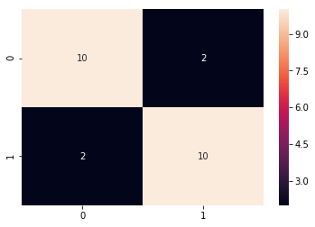

```python
grid_predictions = grid.predict(X_test_scaled)
cm = confusion_matrix(y_test, grid_predictions)
sns.heatmap(cm,annot=True,fmt="d")
```

```python
from sklearn.metrics import  accuracy_score, f1_score, precision_score, recall_score
from sklearn.metrics import roc_auc_score
roc=roc_auc_score(y_test, grid_predictions)
acc = accuracy_score(y_test, grid_predictions)
prec = precision_score(y_test, grid_predictions)
rec = recall_score(y_test, grid_predictions)
f1 = f1_score(y_test, grid_predictions)

model_results = pd.DataFrame([['Random Forest Optimized', acc,prec,rec, f1,roc]],
               columns = ['Model', 'Accuracy', 'Precision', 'Recall', 'F1 Score','ROC'])
results = results.append(model_results, ignore_index = True)
results
```

|  | Model | Accuracy | Precision | Recall | F1 Score | ROC |
| --- | --- | --- | --- | --- | --- | --- |
| 0 | Support Vector Machine Un optimized | 0.500000 | 0.500000 | 1.000000 | 0.666667 | 0.500000 |
| 1 | Support Vector Machine Optimized | 0.875000 | 0.909091 | 0.833333 | 0.869565 | 0.875000 |
| 2 | Random Forest Optimized | 0.833333 | 0.833333 | 0.833333 | 0.833333 | 0.833333 |

```python
from sklearn.ensemble  import AdaBoostClassifier
adaboost =AdaBoostClassifier()
adaboost.fit(X_train_scaled, y_train)
```

```
AdaBoostClassifier(algorithm='SAMME.R', base_estimator=None,
          learning_rate=1.0, n_estimators=50, random_state=None)
```

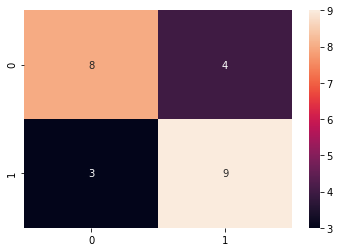

```python
y_predict = adaboost.predict(X_test_scaled)
cm = confusion_matrix(y_test, y_predict)

sns.heatmap(cm,annot=True,fmt="d")
```

```python
from sklearn.metrics import  accuracy_score, f1_score, precision_score, recall_score
from sklearn.metrics import roc_auc_score
roc=roc_auc_score(y_test, y_predict)
acc = accuracy_score(y_test, y_predict)
prec = precision_score(y_test, y_predict)
rec = recall_score(y_test, y_predict)
f1 = f1_score(y_test, y_predict)

model_results = pd.DataFrame([['Adaboost', acc,prec,rec, f1,roc]],
               columns = ['Model', 'Accuracy', 'Precision', 'Recall', 'F1 Score','ROC'])
results = results.append(model_results, ignore_index = True)
results
```

|  | Model | Accuracy | Precision | Recall | F1 Score | ROC |
| --- | --- | --- | --- | --- | --- | --- |
| 0 | Support Vector Machine Un optimized | 0.500000 | 0.500000 | 1.000000 | 0.666667 | 0.500000 |
| 1 | Support Vector Machine Optimized | 0.875000 | 0.909091 | 0.833333 | 0.869565 | 0.875000 |
| 2 | Random Forest Optimized | 0.833333 | 0.833333 | 0.833333 | 0.833333 | 0.833333 |
| 3 | Adaboost | 0.708333 | 0.692308 | 0.750000 | 0.720000 | 0.708333 |

```python
from xgboost import XGBClassifier
xgb_classifier = XGBClassifier()
xgb_classifier.fit(X_train_scaled, y_train, verbose=True)
```

```
XGBClassifier(base_score=0.5, booster='gbtree', colsample_bylevel=1,
       colsample_bytree=1, gamma=0, learning_rate=0.1, max_delta_step=0,
       max_depth=3, min_child_weight=1, missing=None, n_estimators=100,
       n_jobs=1, nthread=None, objective='binary:logistic', random_state=0,
       reg_alpha=0, reg_lambda=1, scale_pos_weight=1, seed=None,
       silent=True, subsample=1)
```

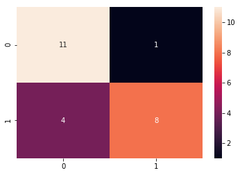

```python
y_predict = xgb_classifier.predict(X_test_scaled)
cm = confusion_matrix(y_test, y_predict)

sns.heatmap(cm,annot=True,fmt="d")
```

```python
from sklearn.metrics import  accuracy_score, f1_score, precision_score, recall_score
from sklearn.metrics import roc_auc_score
roc=roc_auc_score(y_test, y_predict)
acc = accuracy_score(y_test, y_predict)
prec = precision_score(y_test, y_predict)
rec = recall_score(y_test, y_predict)
f1 = f1_score(y_test, y_predict)
from sklearn.metrics import roc_auc_score
roc=roc_auc_score(y_test, y_predict)
model_results = pd.DataFrame([['XGBoost', acc,prec,rec, f1,roc]],
               columns = ['Model', 'Accuracy', 'Precision', 'Recall', 'F1 Score','ROC'])
results = results.append(model_results, ignore_index = True)
results
```

[output not shown]

```python
from sklearn.model_selection import RandomizedSearchCV, cross_val_score
param_dist = {

    'n_estimators':[50,100,120,200,250,500,900,1000,1100,1200,1300,1400,1500],
        'learning_rate': [0.1,0.01,0.2,0.02,0.001],
    'max_depth':[2,3,4,5,6,7,10],
    'booster': ['gbtree','gblinear'],
    'gamma':[0.1,0.01,0.2,0.02,0.001,1,2],
    'random_state':[42],
    'objective':['binary:logistic','reg:linear']
}

# run randomized search
n_iter_search =20
random_search = RandomizedSearchCV(xgb_classifier, param_distributions=param_dist,
                                   n_iter=n_iter_search, cv=5)


random_search.fit(X_train_scaled,y_train)
```

[output not shown]

[output cut: 345 more lines]

[output not shown]

```
RandomizedSearchCV(cv=5, error_score='raise',
          estimator=XGBClassifier(base_score=0.5, booster='gbtree', colsample_bylevel=1,
       colsample_bytree=1, gamma=0, learning_rate=0.1, max_delta_step=0,
       max_depth=3, min_child_weight=1, missing=None, n_estimators=100,
       n_jobs=1, nthread=None, objective='binary:logistic', random_state=0,
       reg_alpha=0, reg_lambda=1, scale_pos_weight=1, seed=None,
       silent=True, subsample=1),
          fit_params=None, iid=True, n_iter=20, n_jobs=1,
          param_distributions={'n_estimators': [50, 100, 120, 200, 250, 500, 900, 1000, 1100, 1200, 1300, 1400, 1500], 'learning_rate': [0.1, 0.01, 0.2, 0.02, 0.001], 'max_depth': [2, 3, 4, 5, 6, 7, 10], 'booster': ['gbtree', 'gblinear'], 'gamma': [0.1, 0.01, 0.2, 0.02, 0.001, 1, 2], 'random_state':…
          pre_dispatch='2*n_jobs', random_state=None, refit=True,
          return_train_score='warn', scoring=None, verbose=0)
```

```python
random_search.best_params_
```

[output not shown]

```python
random_search.best_estimator_
```

```
XGBClassifier(base_score=0.5, booster='gbtree', colsample_bylevel=1,
       colsample_bytree=1, gamma=0.2, learning_rate=0.001,
       max_delta_step=0, max_depth=2, min_child_weight=1, missing=None,
       n_estimators=500, n_jobs=1, nthread=None,
       objective='binary:logistic', random_state=42, reg_alpha=0,
       reg_lambda=1, scale_pos_weight=1, seed=None, silent=True,
       subsample=1)
```

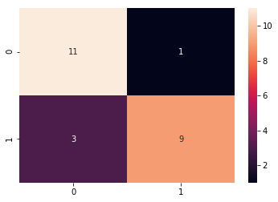

```python
rand_predictions = random_search.predict(X_test_scaled)
cm = confusion_matrix(y_test, rand_predictions)
sns.heatmap(cm,annot=True,fmt="d")
```

```python
from sklearn.metrics import  accuracy_score, f1_score, precision_score, recall_score
acc = accuracy_score(y_test, grid_predictions)
prec = precision_score(y_test, grid_predictions)
rec = recall_score(y_test, grid_predictions)
f1 = f1_score(y_test, grid_predictions)
from sklearn.metrics import roc_auc_score
roc=roc_auc_score(y_test, grid_predictions)
model_results = pd.DataFrame([['XGBoost rand', acc,prec,rec, f1,roc]],
               columns = ['Model', 'Accuracy', 'Precision', 'Recall', 'F1 Score','ROC'])
results = results.append(model_results, ignore_index = True)
results
```

[output not shown]

```python
import time
param_dist ={'kernel': ['sigmoid','rbf','linear'], 'gamma': [1e-2, 1e-3, 1e-4, 1e-5,1e-6,2e-2,2e-3],'C': [0.001, 0.01,0.10, 0.1,0.01,1,10,100,1000]}


# run randomized search
n_iter_search = 8
random_search = RandomizedSearchCV(svc_model, param_distributions=param_dist,n_iter=n_iter_search, cv=5)


random_search.fit(X_train_scaled,y_train)
```

```
RandomizedSearchCV(cv=5, error_score='raise',
          estimator=SVC(C=1.0, cache_size=200, class_weight=None, coef0=0.0,
  decision_function_shape='ovr', degree=3, gamma='auto', kernel='rbf',
  max_iter=-1, probability=False, random_state=None, shrinking=True,
  tol=0.001, verbose=False),
          fit_params=None, iid=True, n_iter=8, n_jobs=1,
          param_distributions={'kernel': ['sigmoid', 'rbf', 'linear'], 'gamma': [0.01, 0.001, 0.0001, 1e-05, 1e-06, 0.02, 0.002], 'C': [0.001, 0.01, 0.1, 0.1, 0.01, 1, 10, 100, 1000]},
          pre_dispatch='2*n_jobs', random_state=None, refit=True,
          return_train_score='warn', scoring=None, verbose=0)
```

```python
random_search.best_params_
```

```
{'kernel': 'linear', 'gamma': 0.001, 'C': 100}
```

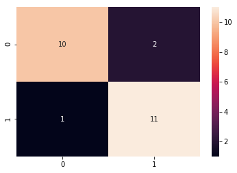

```python
rand_predictions = random_search.predict(X_test_scaled)
cm = confusion_matrix(y_test, rand_predictions)
sns.heatmap(cm,annot=True,fmt="d")
```

```python
from sklearn.metrics import  accuracy_score, f1_score, precision_score, recall_score
acc = accuracy_score(y_test, rand_predictions)
prec = precision_score(y_test, rand_predictions)
rec = recall_score(y_test, rand_predictions)
f1 = f1_score(y_test, rand_predictions)
from sklearn.metrics import roc_auc_score
roc=roc_auc_score(y_test, rand_predictions)
model_results = pd.DataFrame([['SVC Rand linear', acc,prec,rec, f1,roc]],
               columns = ['Model', 'Accuracy', 'Precision', 'Recall', 'F1 Score','ROC'])
results = results.append(model_results, ignore_index = True)
results
```

|  | Model | Accuracy | Precision | Recall | F1 Score | ROC |
| --- | --- | --- | --- | --- | --- | --- |
| 0 | Support Vector Machine Un optimized | 0.500000 | 0.500000 | 1.000000 | 0.666667 | 0.500000 |
| 1 | Support Vector Machine Optimized | 0.875000 | 0.846154 | 0.916667 | 0.880000 | 0.875000 |
| 2 | Random Forest Optimized | 0.833333 | 0.833333 | 0.833333 | 0.833333 | 0.833333 |
| 3 | Adaboost | 0.708333 | 0.692308 | 0.750000 | 0.720000 | 0.708333 |
| 4 | Guassian Naive Bayes | 0.666667 | 0.666667 | 0.666667 | 0.666667 | 0.666667 |
| 5 | XGBoost | 0.791667 | 0.888889 | 0.666667 | 0.761905 | 0.791667 |
| 6 | XGBoost rand | 0.833333 | 0.833333 | 0.833333 | 0.833333 | 0.833333 |
| 7 | SVC Rand linear | 0.875000 | 0.846154 | 0.916667 | 0.880000 | 0.875000 |

```python
from sklearn.linear_model import SGDClassifier
sgd=SGDClassifier(max_iter=1000)
sgd.fit(X_train_scaled, y_train)
```

```
SGDClassifier(alpha=0.0001, average=False, class_weight=None, epsilon=0.1,
       eta0=0.0, fit_intercept=True, l1_ratio=0.15,
       learning_rate='optimal', loss='hinge', max_iter=1000, n_iter=None,
       n_jobs=1, penalty='l2', power_t=0.5, random_state=None,
       shuffle=True, tol=None, verbose=0, warm_start=False)
```

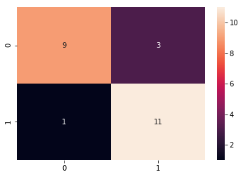

```python
y_predict = sgd.predict(X_test_scaled)
cm = confusion_matrix(y_test, y_predict)

sns.heatmap(cm,annot=True,fmt="d")
```

```python
from sklearn.metrics import  accuracy_score, f1_score, precision_score, recall_score
acc = accuracy_score(y_test, y_predict)
prec = precision_score(y_test, y_predict)
rec = recall_score(y_test, y_predict)
f1 = f1_score(y_test, y_predict)
from sklearn.metrics import roc_auc_score
roc=roc_auc_score(y_test, y_predict)
model_results = pd.DataFrame([['SGD', acc,prec,rec, f1,roc]],
               columns = ['Model', 'Accuracy', 'Precision', 'Recall', 'F1 Score','ROC'])
results = results.append(model_results, ignore_index = True)
results
```

|  | Model | Accuracy | Precision | Recall | F1 Score | ROC |
| --- | --- | --- | --- | --- | --- | --- |
| 0 | Support Vector Machine Un optimized | 0.500000 | 0.500000 | 1.000000 | 0.666667 | 0.500000 |
| 1 | Support Vector Machine Optimized | 0.875000 | 0.846154 | 0.916667 | 0.880000 | 0.875000 |
| 2 | Random Forest Optimized | 0.833333 | 0.833333 | 0.833333 | 0.833333 | 0.833333 |
| 3 | Adaboost | 0.708333 | 0.692308 | 0.750000 | 0.720000 | 0.708333 |
| 4 | Guassian Naive Bayes | 0.666667 | 0.666667 | 0.666667 | 0.666667 | 0.666667 |
| 5 | XGBoost | 0.791667 | 0.888889 | 0.666667 | 0.761905 | 0.791667 |
| 6 | XGBoost rand | 0.833333 | 0.833333 | 0.833333 | 0.833333 | 0.833333 |
| 7 | SVC Rand linear | 0.875000 | 0.846154 | 0.916667 | 0.880000 | 0.875000 |
| 8 | SGD | 0.833333 | 0.785714 | 0.916667 | 0.846154 | 0.833333 |

```python
param_dist ={'max_features': ['auto','sqrt',None], 'n_estimators': [40,45,50,55,60,65,70,80,90,100,150,200,250,300,400,500,600,700,800,900,1000],
             'criterion':['gini','entropy'],'max_depth':[5,6,7,8,9,10,12,15],'random_state': [47]}


# run randomized search
n_iter_search = 69
random_search = RandomizedSearchCV(random_forest , param_distributions=param_dist,n_iter=n_iter_search, cv=5)


random_search.fit(X_train_scaled,y_train)
```

```
RandomizedSearchCV(cv=5, error_score='raise',
          estimator=RandomForestClassifier(bootstrap=True, class_weight=None, criterion='entropy',
            max_depth=None, max_features='auto', max_leaf_nodes=None,
            min_impurity_decrease=0.0, min_impurity_split=None,
            min_samples_leaf=1, min_samples_split=2,
            min_weight_fraction_leaf=0.0, n_estimators=10, n_jobs=1,
            oob_score=False, random_state=42, verbose=0, warm_start=False),
          fit_params=None, iid=True, n_iter=69, n_jobs=1,
          param_distributions={'max_features': ['auto', 'sqrt', None], 'n_estimators': [40, 45, 50, 55, 60, 65, 70, 80, 90, 100, 150, 200, 250, 300, 400, 500, 600, 700, 800, 900, 1000], 'criterion': ['gini', 'entropy'], 'max_depth': [5, 6, 7, 8, 9, 10, 12, 15], 'random_state': [47]},
          pre_dispatch='2*n_jobs', random_state=None, refit=True,
          return_train_score='warn', scoring=None, verbose=0)
```

```python
random_search.best_params_
```

```
{'random_state': 47,
 'n_estimators': 300,
 'max_features': None,
 'max_depth': 8,
 'criterion': 'gini'}
```

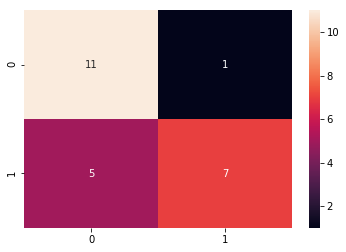

```python
rand_predictions = random_search.predict(X_test_scaled)
cm = confusion_matrix(y_test, rand_predictions)
sns.heatmap(cm,annot=True,fmt="d")
```

```python
from sklearn.metrics import  accuracy_score, f1_score, precision_score, recall_score
acc = accuracy_score(y_test, rand_predictions)
prec = precision_score(y_test, rand_predictions)
rec = recall_score(y_test, rand_predictions)
f1 = f1_score(y_test, rand_predictions)
from sklearn.metrics import roc_auc_score
roc=roc_auc_score(y_test, rand_predictions)
model_results = pd.DataFrame([['Random Search Rand ', acc,prec,rec, f1,roc]],
               columns = ['Model', 'Accuracy', 'Precision', 'Recall', 'F1 Score','ROC'])
results = results.append(model_results, ignore_index = True)
results
```

|  | Model | Accuracy | Precision | Recall | F1 Score | ROC |
| --- | --- | --- | --- | --- | --- | --- |
| 0 | Support Vector Machine Un optimized | 0.500000 | 0.500000 | 1.000000 | 0.666667 | 0.500000 |
| 1 | Support Vector Machine Optimized | 0.875000 | 0.846154 | 0.916667 | 0.880000 | 0.875000 |
| 2 | Random Forest Optimized | 0.833333 | 0.833333 | 0.833333 | 0.833333 | 0.833333 |
| 3 | Adaboost | 0.708333 | 0.692308 | 0.750000 | 0.720000 | 0.708333 |
| 4 | Guassian Naive Bayes | 0.666667 | 0.666667 | 0.666667 | 0.666667 | 0.666667 |
| 5 | XGBoost | 0.791667 | 0.888889 | 0.666667 | 0.761905 | 0.791667 |
| 6 | XGBoost rand | 0.833333 | 0.833333 | 0.833333 | 0.833333 | 0.833333 |
| 7 | SVC Rand linear | 0.875000 | 0.846154 | 0.916667 | 0.880000 | 0.875000 |
| 8 | SGD | 0.833333 | 0.785714 | 0.916667 | 0.846154 | 0.833333 |
| 9 | Random Search Rand | 0.750000 | 0.875000 | 0.583333 | 0.700000 | 0.750000 |

```python
from sklearn import model_selection
from sklearn.linear_model import LogisticRegression
from sklearn.neighbors import KNeighborsClassifier
from sklearn.naive_bayes import GaussianNB
from sklearn.ensemble import RandomForestClassifier
from sklearn.ensemble import AdaBoostClassifier
from mlxtend.classifier import StackingClassifier
from sklearn.linear_model import SGDClassifier
from xgboost import XGBClassifier
import numpy as np

clf1=SVC(C=10, cache_size=200, class_weight=None, coef0=0.0,
  decision_function_shape='ovr', degree=3, gamma=1, kernel='rbf',
  max_iter=-1, probability=False, random_state=None, shrinking=True,
  tol=0.001, verbose=False)
clf2 = RandomForestClassifier(bootstrap=True, class_weight=None, criterion='entropy',
            max_depth=5, max_features='auto', max_leaf_nodes=None,
            min_impurity_decrease=0.0, min_impurity_split=None,
            min_samples_leaf=1, min_samples_split=5,
            min_weight_fraction_leaf=0.0, n_estimators=90, n_jobs=1,
            oob_score=False, random_state=42, verbose=0, warm_start=False)
clf3=AdaBoostClassifier(algorithm='SAMME.R', base_estimator=None,
          learning_rate=1.0, n_estimators=50, random_state=None)

clf4=XGBClassifier(base_score=0.5, booster='gbtree', colsample_bylevel=1,
       colsample_bytree=1, gamma=0.2, learning_rate=0.001,
       max_delta_step=0, max_depth=2, min_child_weight=1, missing=None,
       n_estimators=500, n_jobs=1, nthread=None,
       objective='binary:logistic', random_state=42, reg_alpha=0,
       reg_lambda=1, scale_pos_weight=1, seed=None, silent=True,
       subsample=1)
clf5=SGDClassifier(max_iter=1000)
sclf = StackingClassifier(classifiers=[clf2, clf3, clf4,clf5],
                          meta_classifier=clf1)

print('3-fold cross validation:\n')

for clf, label in zip([clf2, clf3, clf4,clf5, sclf],
                      [
                       'Random Forest',
                       'Adaboost',
                          'XGB','SGD',
                       'StackingClassifier']):

    scores = model_selection.cross_val_score(clf, X_test_scaled, y_test,
                                              cv=10, scoring='accuracy')
    print("Accuracy: %0.2f (+/- %0.2f) [%s]"
          % (scores.mean(), scores.std(), label))
```

```
3-fold cross validation:

Accuracy: 0.88 (+/- 0.20) [Random Forest]
Accuracy: 0.82 (+/- 0.23) [Adaboost]
```

```
Accuracy: 0.78 (+/- 0.24) [XGB]
Accuracy: 0.68 (+/- 0.23) [SGD]
```

[output not shown]

```
Accuracy: 0.88 (+/- 0.20) [StackingClassifier]
```

Great, with the use of stacking of multiple machine learning models we have secured 88% Accuracy with cross validation.